# SALURBAL Jan 2023 Updates

General updates on from Jan 2023

Ran Li

2/6/23

## Overview

- Present GitHub Roadmap for SALURBAL repository/portal
- Overview of SALURBAL 1 infrastructure
- Proposal for SALURBAL 2

## SALURBAL 1 Roadmap: Data Portal

[roadmap link](https://github.com/orgs/Drexel-UHC/projects/1/views/27)

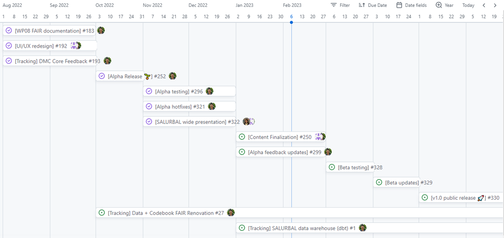

## FAIR Renovation Intro

- Key strengths of SALURBAL: multi-national, multi-year, multi-source, harmonized. However, this is also a challenge for data stewardship.
- We harmonized such complex data have in the past relied on people to organize, distribute and leverage this data
- FAIR renovation is about structuring SALURBAL data and metadata and storing it is machine actionable.

## Renovation Oct - Jan progress

- On boarding of renovation team
- refining our [`structure`](https://drexel-uhc.github.io/salurbal-fair-renovations/pages/blog/data-models/) in a way that fits well with SALURBAL data
- establishing a [prototype data warehouse](https://drexel-uhc.github.io/salurbal-dbt/#!/overview) where renovated data will sit

## SALURBAL 2 proposals

- SALURBAL data warehouse will be primary method of distribution.
  - single source of truth for our project
  - accessible documentation of data transformations
  - automated testing for data integrity
  - automate data distribution via a mature data warehousing system
  - **less human intensive, machine actionable, and more precise/efficient, distribution of data**
- SALURBAL data warehouse will document and distribute data into various different downstream uses:
  - Manuscripts
  - Data Portal
  - Analytic tools
  - Digital journalism content
- Meeting with Usama, Katie, Andrea to be on the same page across SALURBAL 2 Aims.